# Relatório Curso CD

Rejane Finotti

2026-04-23

## Poluição e doenças respiratórias em Mato Grosso

### Introdução

A poluição atmosférica por material particulado fino (PM2,5) é reconhecida como um importante fator de risco para a saúde humana, estando associada ao aumento da morbimortalidade por doenças respiratórias. No estado de Mato Grosso, esse problema apresenta forte componente sazonal, especialmente durante o período seco, quando a intensificação das queimadas e incêndios florestais contribui para a elevação das concentrações de poluentes na atmosfera.

Por outro lado, as doenças respiratórias também apresentam comportamento sazonal, influenciado por fatores climáticos, ambientais e epidemiológicos. No contexto regional, observa-se que o maior volume de internações por doenças respiratórias ocorre predominantemente nos meses de chuva, período caracterizado por maior circulação de vírus respiratórios, mudanças de temperatura e condições ambientais que favorecem a transmissão de agentes infecciosos. Esse padrão indica que a dinâmica desses agravos não está associada exclusivamente à poluição atmosférica, mas resulta da interação entre múltiplos determinantes.

### Objetivo

Descrever a distribuição mensal das concentrações máximas diárias de PM2,5 e das internações por doenças respiratórias no estado de Mato Grosso, no ano de 2024, a fim de identificar padrões sazonais distintos, variações intra e intermensais e possíveis relações temporais entre exposição ambiental e desfechos em saúde.

#### Pacotes

```r
library(tidyverse)
library(readxl)
library(lubridate)
library(ggridges)
library(viridis)
library(sf)
library(leaflet)
library(gganimate)
library(gifski)
library(transformr)
```

```r
library(highcharter)
```

#### Diretorio

```r
pm25 <- read_csv('../dados/pm25_max_mean_MT.csv')
sih  <- read_excel('../dados/SIH_2011-2026.xlsx')
```

### Organizando os meses

```r
mes_map <- c(
  Jan = "janeiro",
  Fev = "fevereiro",
  Mar = "marco",
  Abr = "abril",
  Mai = "maio",
  Jun = "junho",
  Jul = "julho",
  Ago = "agosto",
  Set = "setembro",
  Out = "outubro",
  Nov = "novembro",
  Dez = "dezembro"
)
```

### Base Material Particulado (PM25)

```r
ordem_meses <- c(
  "janeiro", "fevereiro", "marco", "abril", "maio", "junho",
  "julho", "agosto", "setembro", "outubro", "novembro", "dezembro"
)

pm25_2024 <- pm25 |>
  mutate(
    ano = year(date),
    mes_num = month(date),
    mes = factor(mes_num, levels = 1:12, labels = ordem_meses)
  ) |>
  filter(ano == 2024) |>
  group_by(date, mes) |>
  summarise(
    pm25_max = max(value, na.rm = TRUE),
    .groups = "drop"
  ) |>
  filter(is.finite(pm25_max))

# retirar valores extremos
limite_pm25 <- quantile(pm25_2024$pm25_max, 0.99, na.rm = TRUE)

pm25_2024 <- pm25_2024 |>
  filter(pm25_max <= limite_pm25)

# conferir se tem dados
nrow(pm25_2024)
```

```
## [1] 362
```

```r
table(pm25_2024$mes, useNA = "always")
```

```
##
##   janeiro fevereiro     marco     abril      maio     junho     julho    agosto
##        31        29        31        30        31        30        31        30
##  setembro   outubro  novembro  dezembro      <NA>
##        27        31        30        31         0
```

```r
summary(pm25_2024$pm25_max)
```

```
##    Min. 1st Qu.  Median    Mean 3rd Qu.    Max.
##   14.21   32.14   62.73  204.05  180.64 1789.49
```

#### Gráfico da distribução dos valores máximos diários do PM25 em Mato Grosso no ano de 2024

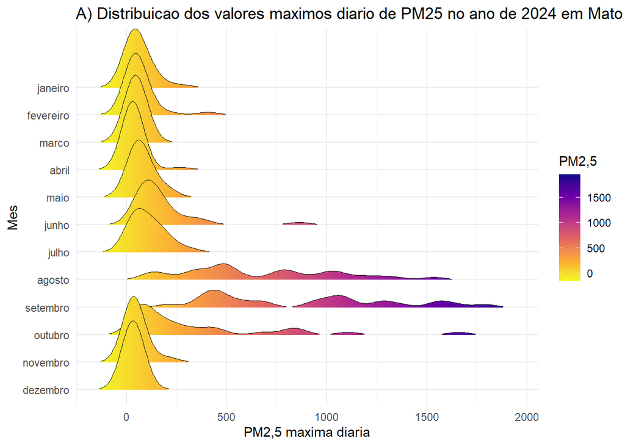

```r
grafico_pm25 <- ggplot(
  pm25_2024,
  aes(
    x = pm25_max,
    y = fct_rev(mes),
    fill = after_stat(x)
  )
) +
  geom_density_ridges_gradient(
    scale = 2.5,
    rel_min_height = 0.01,
    color = "black",
    linewidth = 0.3
  ) +
  scale_fill_viridis_c(
    option = "C",
    direction = -1,
    name = "PM2,5"
  ) +
  labs(
    title = "A) Distribuicao dos valores maximos diario de PM25 no ano de 2024 em Mato Grosso",
    x = "PM2,5 maxima diaria",
    y = "Mes"
  ) +
  theme_minimal()

grafico_pm25
```

Observa-se um padrão sazonal bem definido na concentração máxima diária de PM2,5 em Mato Grosso ao longo de 2024. Nos primeiros meses do ano, de janeiro a junho, predominam valores baixos e pouca variabilidade, com distribuições concentradas próximas de zero. A partir de julho, observa-se um aumento progressivo das concentrações, com maior dispersão e deslocamento das distribuições para valores mais elevados.

Os meses de agosto e setembro apresentam os maiores níveis de PM2,5, com ampla variabilidade e ocorrência de valores extremos, indicando episódios intensos de poluição atmosférica. Esse comportamento é compatível com o período seco na região, caracterizado pela intensificação das queimadas. A partir de outubro, há redução gradual das concentrações, com retorno a níveis mais baixos e menor variabilidade nos meses de novembro e dezembro, acompanhando o início do período chuvoso.

###Base Internações por doenças respiratorias (SIH)

```r
ordem_meses <- c(
  "janeiro", "fevereiro", "marco", "abril", "maio", "junho",
  "julho", "agosto", "setembro", "outubro", "novembro", "dezembro"
)

sih_2024_resp <- sih |>
  mutate(
    AnoInternacao = as.numeric(AnoInternacao),
    DiaInternacao = as.numeric(DiaInternacao),
    NumeroInternacoes = as.numeric(NumeroInternacoes),
    mes_abrev = str_sub(MesInternacao, 4, 6),
    mes = mes_map[mes_abrev],
    mes = factor(mes, levels = ordem_meses)
  ) |>
  filter(AnoInternacao == 2024)

sih_diario_2024 <- sih_2024_resp |>
  group_by(mes, DiaInternacao) |>
  summarise(
    internacoes = sum(NumeroInternacoes, na.rm = TRUE),
    .groups = "drop"
  )
```

### Grafico com a distribição mensal por doenças respiratórias em Mato Grosso, no ano de 2024

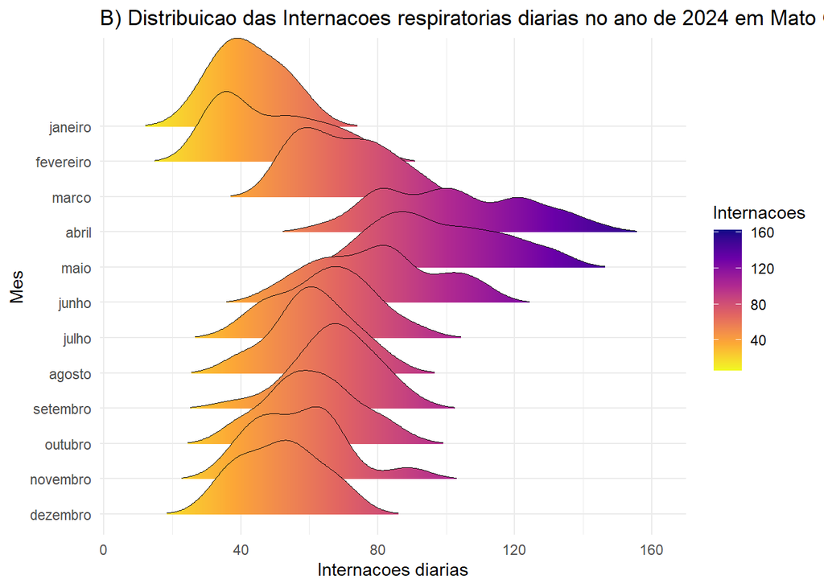

```r
grafico_sih <- ggplot(
  sih_diario_2024,
  aes(
    x = internacoes,
    y = fct_rev(mes),
    fill = after_stat(x)
  )
) +
  geom_density_ridges_gradient(
    scale = 2.5,
    rel_min_height = 0.01,
    color = "black",
    linewidth = 0.3
  ) +
  scale_fill_viridis_c(
    option = "C",
    direction = -1,
    name = "Internacoes"
  ) +
  labs(
    title = "B) Distribuicao das Internacoes respiratorias diarias no ano de 2024 em Mato Grosso",
    x = "Internacoes diarias",
    y = "Mes"
  ) +
  theme_minimal()

grafico_sih
```

O gráfico evidencia um padrão sazonal na distribuição das internações respiratórias diárias em Mato Grosso ao longo de 2024. Nos primeiros meses do ano, especialmente entre janeiro e fevereiro, as internações apresentam valores mais baixos e menor variabilidade. A partir de março, observa-se um aumento progressivo, com maior dispersão e deslocamento das distribuições para valores mais elevados.

Os meses de abril e maio concentram os maiores volumes de internações, com ocorrência de valores mais altos e maior heterogeneidade, indicando períodos de maior demanda por serviços de saúde. Após esse pico, verifica-se uma redução gradual das internações a partir de junho, mantendo-se em níveis intermediários até outubro, com nova diminuição nos meses finais do ano.

```r
# arrumando os dados diários
pm25_diario_2024 <- pm25 %>%
  mutate(
    date = as.Date(date),
    ano = year(date)
  ) %>%
  filter(ano == 2024) %>%
  group_by(date) %>%
  summarise(
    pm25_diario = mean(value, na.rm = TRUE),
    .groups = "drop"
  ) %>%
  mutate(
    dia_semana = weekdays(date),
    data_label = format(date, "%B %d, %Y")
  )

# grafico interativo distribuição diaria PM2,5

grafico_pm25_diario <- highchart() %>%
  hc_add_series(
    data = pm25_diario_2024,
    type = "line",
    hcaes(
      x = date,
      y = pm25_diario
    ),
    name = "PM2,5 diário"
  ) %>%
  hc_title(
    text = "Distribuição diária do PM2,5 em Mato Grosso - 2024"
  ) %>%
  hc_subtitle(
    text = "Concentração média diária de PM2,5"
  ) %>%
  hc_xAxis(
    type = "datetime",
    title = list(text = "Data")
  ) %>%
  hc_yAxis(
    title = list(text = "PM2,5 (µg/m³)")
  ) %>%
  hc_tooltip(
    useHTML = TRUE,
    pointFormat = paste0(
      "<b>{point.dia_semana}, {point.data_label}</b><br>",
      "PM2,5 disperso: <b>{point.y:.2f}</b> µg/m³"
    )
  ) %>%
  hc_exporting(enabled = TRUE)

grafico_pm25_diario
```

[interactive chart not shown]

A partir do mes de julho, observa-se um aumento progressivo das concentrações, coincidindo com o início do período seco no estado. Em agosto e, principalmente, setembro, os níveis tornam-se extremamente elevados, com diversos episódios acima de 100 µg/m³ e um pico superior a 600 µg/m³, valores muito acima do limite diário considerado seguro pela Organização Mundial da Saúde (OMS), estabelecido em 15 µg/m³, indicando severa degradação da qualidade do ar.

```r
library(sf)

mt_mapa <- st_read("../dados/MT_Municipios_2023.shp") |>
  st_transform(4326)
```

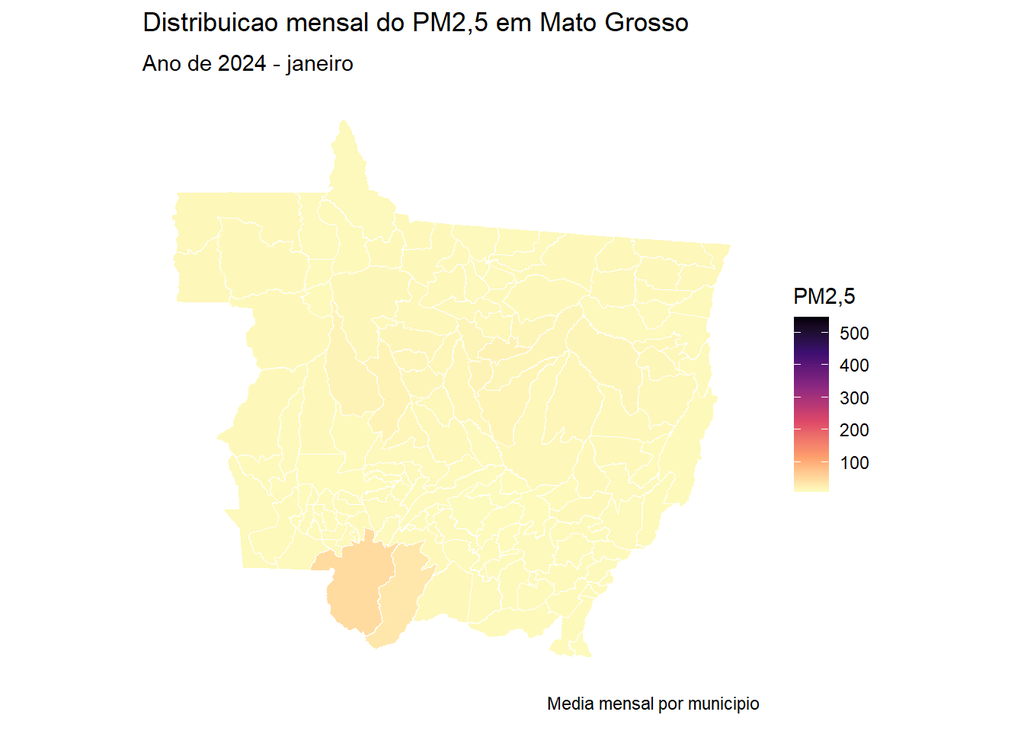

```r
# Pacotes adicionais ------------------------------------------------------

library(gganimate)
library(gifski)
library(transformr)


# Base mensal PM2,5 -------------------------------------------------------

pm25_mes_2024 <- pm25 |>
  mutate(
    ano = year(date),
    mes = month(date),
    code_muni = str_sub(as.character(code_muni), 1, 6)
  ) |>
  filter(ano == 2024) |>
  group_by(code_muni, mes) |>
  summarise(
    pm25_media = mean(value, na.rm = TRUE),
    .groups = "drop"
  ) |>
  mutate(
    mes_nome = factor(
      mes,
      levels = 1:12,
      labels = ordem_meses
    )
  )


# Mapa com PM2,5 mensal ---------------------------------------------------

mapa_pm25_mes <- mt_mapa |>
  st_transform(4326) |>
  mutate(
    code_muni = str_sub(as.character(CD_MUN), 1, 6)
  ) |>
  left_join(pm25_mes_2024, by = "code_muni")


# Escala fixa -------------------------------------------------------------

limites_pm25 <- range(mapa_pm25_mes$pm25_media, na.rm = TRUE)


# Animação ----------------------------------------------------------------

g_pm25_anim <- ggplot(mapa_pm25_mes) +
  geom_sf(aes(fill = pm25_media), color = "white", linewidth = 0.08) +
  scale_fill_viridis_c(
    option = "magma",
    direction = -1,
    limits = limites_pm25,
    na.value = "grey90",
    name = "PM2,5"
  ) +
  labs(
    title = "Distribuicao mensal do PM2,5 em Mato Grosso",
    subtitle = "Ano de 2024 - {closest_state}",
    caption = "Media mensal por municipio",
    fill = "PM2,5"
  ) +
  theme_minimal() +
  theme(
    panel.grid = element_blank(),
    axis.text = element_blank(),
    axis.title = element_blank(),
    plot.title = element_text(face = "bold"),
    legend.position = "right"
  ) +
  transition_states(
    mes_nome,
    transition_length = 2,
    state_length = 3,
    wrap = TRUE
  ) +
  ease_aes("linear")

g_pm25_anim
```